# Refraction of a laser beam

This code adds three gaussian beams, an incident beam, a reflected beam and a refracted beam.

```python
import matplotlib.pyplot as plt
import numpy as np
```

# Gaussian beam propagation

The gaussian beam propagation is calculated using the complex beam parameter, see e.g. p. 178 in *Optics f2f*, https://global.oup.com/ukhe/product/optics-f2f-9780198786795?cc=gb&lang=en&

The function below is called successively for the incident, reflected and refracted beams. The angles and positions of the waist for each component are calculated using geometrical optics.

```python
def gbeam(x,y,x0,y0,angle):
    angle = angle - np.pi/2
    xa = (x-x0)*np.cos(angle) + (y-y0)*np.sin(angle)
    ya = (y-y0)*np.cos(angle) - (x-x0)*np.sin(angle)
    w0 = 2.0
    zR = np.pi*w0*w0
    q = ya-1.j*zR
    return (-1.j*zR*np.exp(2*np.pi*1.j*(ya+xa*xa/(2*q)))/q)
```

# Create an image

The next cell create a single image. If you do not want an animation this is all you need. The code uses separate RGB channels which is not really exploited here but could be used to illustrate dispersion. Also note that in this version each beam has the same amplitude which is non-physical. Plan is to include correct Fresnel reflectivities later.

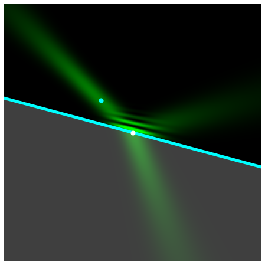

```python
n1 = 1.0 # incoming refractive index
eps = 1e-8 # offset to avoid infinities
xp = -5.0 # incident beam waist coordinates
yp = -5.0
xmc = 0 # mirror centre coordinates
ymc = 0

theta_m = 15*np.pi/180 + eps # Mirror angle
a = np.tan(theta_m)
xmax = 20
b = ymc - a * xmc
xc = (yp + xp/a - b)/(a+1/a) # tangent from mirror to (xp,yp) is at (xc,yc)
yc = a*xc + b
xm = xc + xc - xp # (xm,ym) are virtual waist position of reflected beam
ym = yc + yc - yp

fig, ax = plt.subplots(1,1,figsize=(8, 8))
theta_i = 45 * np.pi/180 + 2*eps # incident angle
xi = (yp - b - xp*np.tan(theta_i))/(np.tan(theta_m) - np.tan(theta_i))
yi = (xi - xp)*np.tan(theta_i) + yp # (xi,yi) position incident beam hits mirror
dx = 0.05 # spatial resolution in units of the wavelength
zoom = 1
X, Y = np.mgrid[-xmax/zoom:xmax/zoom:dx/zoom,-xmax/zoom:xmax/zoom:dx/zoom]
x_pts, y_pts = np.shape(X)
theta_m_dash = np.pi/2 - theta_m
if theta_m > 0:
    M1 = - np.tan(theta_m_dash)*X + Y < b # add shading on one side of mirror
else:
    M1 = - np.tan(theta_m_dash)*X + Y > b # add shading on one side of mirror

Intensity = np.zeros((x_pts,y_pts))
E = 1/np.sqrt(2)*gbeam(X,Y,xp,yp,theta_i) #add incident beam
theta_r = - theta_i + 2*theta_m # for reflected rate offset angle by 2 * mirror angle
E -= 1/np.sqrt(2)*gbeam(X,Y,xm,ym,theta_r) #add reflected beam

Intensity = E.real * E.real + E.imag * E.imag

R = np.zeros((x_pts,y_pts))
G = np.zeros((x_pts,y_pts))
B = np.zeros((x_pts,y_pts))

G += np.swapaxes(Intensity,0,1)*(1-M1) #add to green channel (1-M1) set field below mirror to zero.
n2 = 1.5 # outgoing refractive index
i = np.pi/2 - theta_i + theta_m
sin_t = (n1/n2)*np.sin(i) # the law of Ibn Sahl (also named after Descartes and Snell)
l = np.sqrt((xp-xi)**2 + (yp-yi)**2)

if sin_t < 1:
    t = np.arcsin(sin_t)
    theta_t = np.pi/2 - t + theta_m # refracted beam angle
    xv = -l*np.cos(theta_t) + xi # (xv,yv) coordinates of waist of refracted beam
    yv = -l*np.sin(theta_t) + yi
    E = 1/np.sqrt(2)*gbeam(X, Y, xv, yv, theta_t)
else:
    E = np.zeros((x_pts,y_pts))

Intensity = E.real * E.real + E.imag * E.imag
G += np.swapaxes(Intensity,0,1) *M1 # add refracted beam below interface.

R +=  0.25*M1  # add shading for glass
G +=  0.25*M1
B +=  0.25*M1

R = np.clip(R,0.0,1.0) # RGB values need to be in range 0 to 1!
G = np.clip(G,0.0,1.0)
B = np.clip(B,0.0,1.0)

RGB = np.dstack((R, G, B)) # format required for image.

ax.imshow(RGB) # show image
ax.set_axis_off()
x = np.arange(-xmax,xmax,0.1) # these 5 lines add a blue line along interface and some key points
y = a*x + b
ax.plot(x/dx+x_pts/2,y/dx+y_pts/2,color = [0, 1, 1], alpha=1.0,zorder=2, linewidth = 5)
ax.scatter(xp/dx+x_pts/2,yp/dx+x_pts/2, color = [0, 1, 1], s=50, alpha = 1.0, zorder=3)
ax.scatter(xi/dx+x_pts/2,yi/dx+x_pts/2, color = [1, 1, 1], s=50, alpha = 1.0, zorder=3)
```

# Creating the image files

Now the figure code is run for a range of mirror angles and each image saved to a separate .png file.

```python
frame_storage_path = './tmp/frames/{}.png'

mirror_angles = np.arange(-20,45,1)
n_frames = np.size(mirror_angles)

n1 = 1.0 # incoming refractive index
eps = 1e-8 # offset to avoid infinities
xp = -5.0 # incident beam waist coordinates
yp = -5.0
xmc = 0 # mirror centre coordinates
ymc = 0

for frame_id in range(0,n_frames):
    theta_m = -mirror_angles[frame_id]*np.pi/180 + eps # Mirror angle
    a = np.tan(theta_m)
    xmax = 20
    b = ymc - a * xmc
    xc = (yp + xp/a - b)/(a+1/a) # tangent from mirror to (xp,yp) is at (xc,yc)
    yc = a*xc + b
    xm = xc + xc - xp # (xm,ym) are virtual waist position of reflected beam
    ym = yc + yc - yp

    fig, ax = plt.subplots(1,1,figsize=(8, 8))
    theta_i = 45 * np.pi/180 + 2*eps # incident angle
    xi = (yp - b - xp*np.tan(theta_i))/(np.tan(theta_m) - np.tan(theta_i))
    yi = (xi - xp)*np.tan(theta_i) + yp # (xi,yi) position incident beam hits mirror
    dx = 0.05 # spatial resolution in units of the wavelength
    zoom = 1
    X, Y = np.mgrid[-xmax/zoom:xmax/zoom:dx/zoom,-xmax/zoom:xmax/zoom:dx/zoom]
    x_pts, y_pts = np.shape(X)
    theta_m_dash = np.pi/2 - theta_m
    if theta_m > 0:
        M1 = - np.tan(theta_m_dash)*X + Y < b # add shading on one side of mirror
    else:
        M1 = - np.tan(theta_m_dash)*X + Y > b # add shading on one side of mirror

    Intensity = np.zeros((x_pts,y_pts))
    E = 1/np.sqrt(2)*gbeam(X,Y,xp,yp,theta_i) #add incident beam
    theta_r = - theta_i + 2*theta_m # for reflected rate offset angle by 2 * mirror angle
    E -= 1/np.sqrt(2)*gbeam(X,Y,xm,ym,theta_r) #add reflected beam

    Intensity = E.real * E.real + E.imag * E.imag

    R = np.zeros((x_pts,y_pts))
    G = np.zeros((x_pts,y_pts))
    B = np.zeros((x_pts,y_pts))

    G += np.swapaxes(Intensity,0,1)*(1-M1) #add to green channel (1-M1) set field below mirror to zero.
    n2 = 1.5 # outgoing refractive index
    i = np.pi/2 - theta_i + theta_m
    sin_t = (n1/n2)*np.sin(i) # the law of Ibn Sahl (also named after Descartes and Snell)
    l = np.sqrt((xp-xi)**2 + (yp-yi)**2)

    if sin_t < 1:
        t = np.arcsin(sin_t)
        theta_t = np.pi/2 - t + theta_m # refracted beam angle
        xv = -l*np.cos(theta_t) + xi # (xv,yv) coordinates of waist of refracted beam
        yv = -l*np.sin(theta_t) + yi
        E = 1/np.sqrt(2)*gbeam(X, Y, xv, yv, theta_t)
    else:
        E = np.zeros((x_pts,y_pts))

    Intensity = E.real * E.real + E.imag * E.imag
    G += np.swapaxes(Intensity,0,1) *M1 # add refracted beam below interface.

    R +=  0.25*M1  # add shading for glass
    G +=  0.25*M1
    B +=  0.25*M1

    R = np.clip(R,0.0,1.0) # RGB values need to be in range 0 to 1!
    G = np.clip(G,0.0,1.0)
    B = np.clip(B,0.0,1.0)

    RGB = np.dstack((R, G, B)) # format required for image.

    ax.imshow(RGB) # show image
    ax.set_axis_off()
    x = np.arange(-xmax,xmax,0.1) # these 5 lines add a blue line along interface and some key points
    y = a*x + b
    ax.plot(x/dx+x_pts/2,y/dx+y_pts/2,color = [0, 1, 1], alpha=1.0,zorder=2, linewidth = 5)
    ax.scatter(xp/dx+x_pts/2,yp/dx+x_pts/2, color = [0, 1, 1], s=50, alpha = 1.0, zorder=3)
    ax.scatter(xi/dx+x_pts/2,yi/dx+x_pts/2, color = [1, 1, 1], s=50, alpha = 1.0, zorder=3)

    file_name = f'{frame_id:05}'
    file_path = frame_storage_path.format(file_name)
    fig.savefig(file_path)
    plt.close() # do not show images in notebook as there are loads.
    ax.clear()
```

# Convert images to gif

Finally, we put all the png files into a gif. For the command below to work you will need to have ffmpeg installed. There are many other ways to do animations in matplotlib.

```python
!ffmpeg -pattern_type glob -i './tmp/frames/*.png' -y out1.gif
```

[output not shown]